# What types of crimes are different victim demographics more likely to experience?

shujun (chloe) Yang

[View midterm.html on GitHub](https://github.com/ChloeShujunYang/JSC370-labs/blob/main/midterm)

## Introduction

Crime is a major concern in urban areas, and understanding the patterns of victimization can help improve public safety. In this project, I am analyzing a large dataset of reported crimes from Los Angeles, which includes details about crime type, victim demographics (such as gender, age, and ethnicity), and other relevant factors. The dataset is sourced from Los Angeles Open Data and contains millions of records covering various types of offenses over several years.

The goal of my analysis is to explore how victim demographics influence the type of crime they experience. Specifically, I aim to answer the following questions:

Do different genders experience different types of crimes? Are certain age groups more vulnerable to specific crimes? How does crime type vary across different ethnic groups? Can we predict the most likely crime a person might experience based on their demographics? To answer these questions, I will conduct statistical analyses, visualize trends using heatmaps and bar charts, and ultimately develop a machine learning model to predict crime risks based on victim attributes. The findings could provide insights into crime prevention efforts and help identify high-risk individuals who may need additional safety measures.

## Method

### Data Source and Preprocessing

The dataset used in this analysis comes from Los Angeles Open Data, specifically the Crime Data from 2020 to Present provided by the Los Angeles Police Department (LAPD). This dataset includes incidents of crime reported in Los Angeles since 2020, covering various crime types along with victim demographics such as age, gender, and ethnicity. The data is sourced via an API request and contains records transcribed from original crime reports

To ensure data quality, I performed extensive preprocessing on the dataset using R (tidyverse, dplyr, lubridate). First, I converted date columns to Date format and standardized time values to extract the hour of occurrence. Categorical variables such as vict_sex and vict_descent were factorized for easier analysis.

Missing values in categorical columns (crm_cd_desc, status_desc, premis_desc, mocodes, vict_sex, vict_descent) were replaced with “Unknown”, while numerical columns (vict_age) were imputed with the median value after filtering out invalid values (e.g., negative ages and zeros). I also filled missing values in premis_cd using the most frequent category.

To ensure geographical accuracy, I removed records with invalid latitude and longitude values (e.g., lat=0, lon=0). Additionally, crime descriptions (crm_cd_desc) were standardized and simplified for clarity, and ethnic codes were mapped to full labels (e.g., “B” → “Black”, “H” → “Hispanic/Latin/Mexican”). Finally, I dropped high-missing-value columns such as crm_cd_2, weapon_used_cd, and cross_street, and removed records with “Other” or “Unknown” ethnicity to maintain consistency in demographic analysis.

### Exploratory Data Analysis (EDA)

To analyze how victim demographics influence crime type, I generated three key visualizations using ggplot2. The first compares crime types by gender, showing that men are more likely to experience violent crimes (e.g., robbery, aggravated assault), while women are more frequently victims of domestic assault and identity theft. The second visualization explores crime distribution by age group, highlighting that younger victims are more prone to physical crimes, whereas older individuals face a higher risk of financial crimes. Lastly, I examined crime type distribution by ethnicity, revealing that Black and Hispanic victims report more violent crimes, while White and Asian victims experience higher rates of identity theft and property crimes. These patterns confirm that my research question is valid, as clear demographic trends emerge in crime victimization.

Following are the three EDA graphes:

1. Victim Gender vs. Crime Type

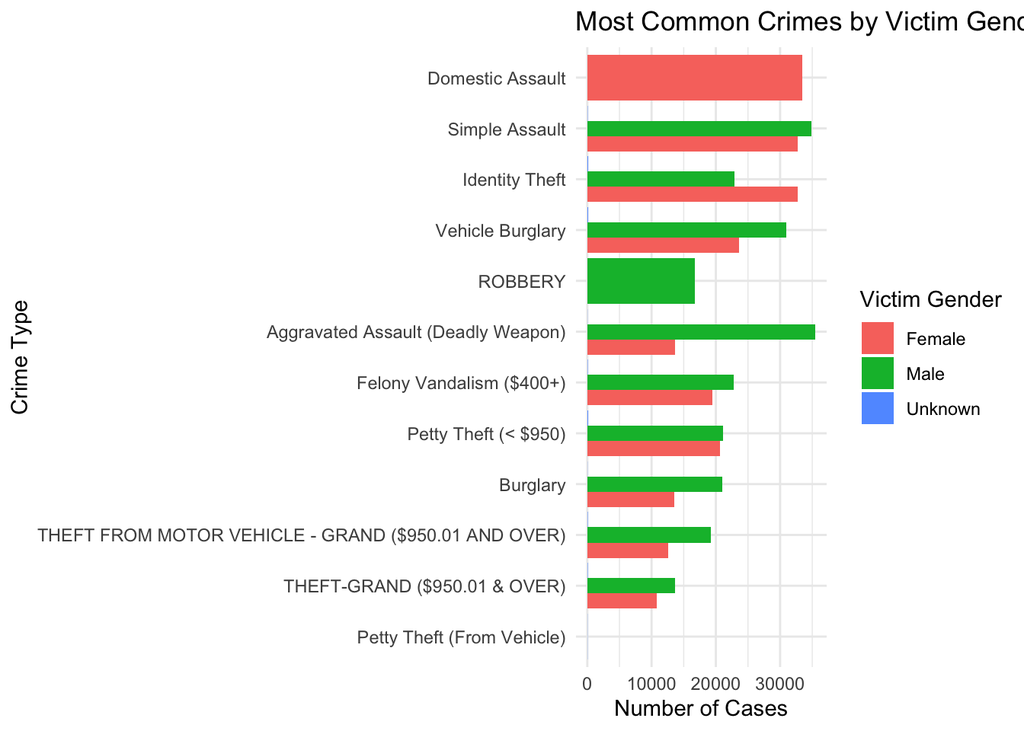

2. Victim Age vs. Crime Type

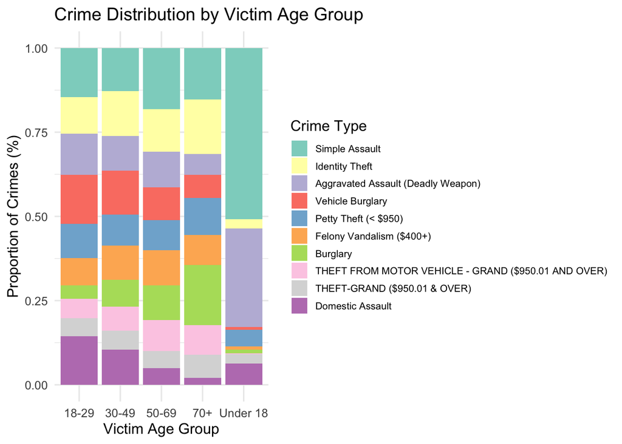

3.Victim Ethnicity vs. Crime Type

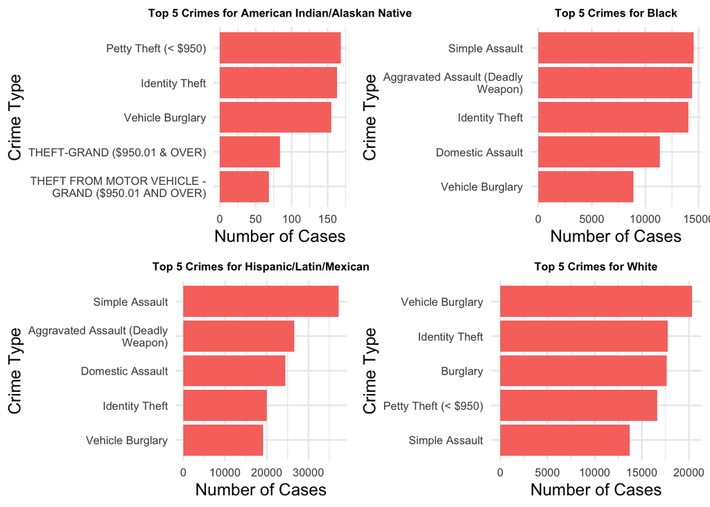

After completing the EDA, I confirmed that my hypothesis was reasonable. Next, I conducted chi-square tests for each of the three key questions to statistically verify that gender, age, and ethnicity significantly influence the types of crimes victims are most likely to experience.

### Chi-Square Test and Analysis

**1. Do men and women experience different types of crimes?**

**Method**

To answer this, crimes were grouped into seven types:

- Assault (e.g., domestic assault, aggravated assault)
- Fraud (e.g., identity theft, credit card fraud)
- Property Damage (e.g., vandalism, arson)
- Public Order (e.g., stalking, resisting arrest)
- Sexual Crimes (e.g., rape, lewd conduct)
- Theft (e.g., burglary, vehicle theft)
- Violent Crimes (e.g., robbery, homicide)

A table was created to compare victim gender across crime types. A Chi-Square Test was used to check if gender and crime type are related.

**Analysis**

The p-value is very small (p < 0.001), confirming a strong connection between gender and crime type.

Women are more often victims of assault, fraud, and sexual crimes. This aligns with EDA findings, where domestic assault and identity theft were more common for female victims.

Men are more often victims of theft, violent crimes, and property damage. This matches EDA results, which showed more burglary, robbery, and vandalism cases involving male victims.

Public order crimes are more frequent among female victims, supporting EDA observations on stalking and harassment. This also aligns with the trend we observed in the heatmap.

Crime Type Distribution by Victim Gender

| Victim Gender | Crime Type | Count |
| --- | --- | --- |
| Female | Assault | 105858 |
| Male | Assault | 97038 |
| Unknown | Assault | 107 |
| Female | Fraud | 34365 |
| Male | Fraud | 25750 |
| Unknown | Fraud | 119 |
| Female | Property_Damage | 30807 |
| Male | Property_Damage | 34781 |
| Unknown | Property_Damage | 79 |
| Female | Public_Order | 30267 |
| Male | Public_Order | 16945 |
| Unknown | Public_Order | 34 |
| Female | Sexual_Crimes | 8970 |
| Male | Sexual_Crimes | 1336 |
| Unknown | Sexual_Crimes | 5 |
| Female | Theft | 103346 |
| Male | Theft | 137514 |
| Unknown | Theft | 487 |
| Female | Violent_Crimes | 13804 |
| Male | Violent_Crimes | 29661 |
| Unknown | Violent_Crimes | 23 |

Chi-Square Test Results for Gender and Crime Type

| Chi-Square | DF | P-Value |
| --- | --- | --- |
| 21,814.26 | 12 | < 2.22e-16 |

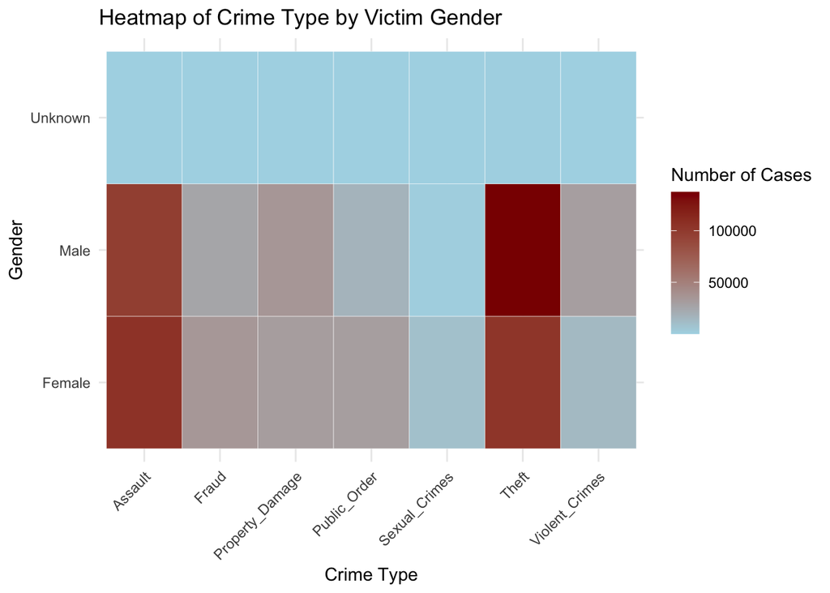

**2. Do different age groups experience different types of crimes?**

**Method**

To answer this, crimes were grouped into seven types as before:

- Assault (e.g., domestic assault, aggravated assault)
- Fraud (e.g., identity theft, credit card fraud)
- Property Damage (e.g., vandalism, arson)
- Public Order (e.g., stalking, resisting arrest)
- Sexual Crimes (e.g., rape, lewd conduct)
- Theft (e.g., burglary, vehicle theft)
- Violent Crimes (e.g., robbery, homicide)

A table was created to compare crime types across different age groups. A Chi-Square Test was used to check if age group and crime type are related.

**Analysis**

The p-value is very small (p < 0.001), confirming a strong connection between age group and crime type.

Individuals aged 30-49 experience the highest number of crimes overall, especially theft and assault. This aligns with EDA findings, where this age group had the most reported incidents.

Younger individuals (under 18) have a higher proportion of sexual crimes, which matches EDA observations. Older individuals (70+) experience fewer crimes overall, but fraud and property damage are relatively more common among them.

Public order crimes are most frequent in the 30-49 age group, supporting EDA findings on offenses like stalking and resisting arrest. The overall trend suggests that crime type varies significantly by age group.

Crime Type Distribution by Victim Age Group

| Age Group | Crime Type | Count |
| --- | --- | --- |
| 18-29 | Assault | 58083 |
| 30-49 | Assault | 88667 |
| 50-69 | Assault | 39036 |
| 70+ | Assault | 5190 |
| Under 18 | Assault | 12027 |
| 18-29 | Fraud | 13333 |
| 30-49 | Fraud | 29606 |
| 50-69 | Fraud | 13263 |
| 70+ | Fraud | 3595 |
| Under 18 | Fraud | 437 |
| 18-29 | Property_Damage | 13974 |
| 30-49 | Property_Damage | 32404 |
| 50-69 | Property_Damage | 16157 |
| 70+ | Property_Damage | 2888 |
| Under 18 | Property_Damage | 244 |
| 18-29 | Public_Order | 9214 |
| 30-49 | Public_Order | 22321 |
| 50-69 | Public_Order | 9959 |
| 70+ | Public_Order | 2194 |
| Under 18 | Public_Order | 3558 |
| 18-29 | Sexual_Crimes | 2674 |
| 30-49 | Sexual_Crimes | 2444 |
| 50-69 | Sexual_Crimes | 651 |
| 70+ | Sexual_Crimes | 65 |
| Under 18 | Sexual_Crimes | 4477 |
| 18-29 | Theft | 60929 |
| 30-49 | Theft | 114021 |
| 50-69 | Theft | 52542 |
| 70+ | Theft | 12729 |
| Under 18 | Theft | 1126 |
| 18-29 | Violent_Crimes | 12480 |
| 30-49 | Violent_Crimes | 19023 |
| 50-69 | Violent_Crimes | 8616 |
| 70+ | Violent_Crimes | 1096 |
| Under 18 | Violent_Crimes | 2273 |

Chi-Square Test Results for Age Group and Crime Type

| Chi-Square | DF | P-Value |
| --- | --- | --- |
| 69,869.05 | 24 | < 2.22e-16 |

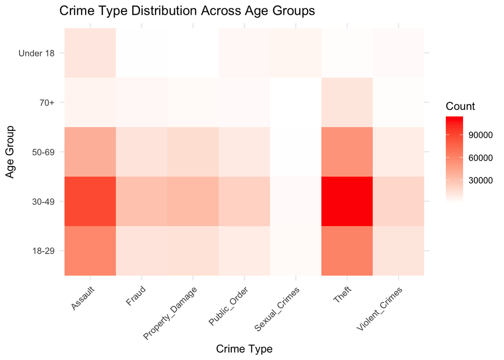

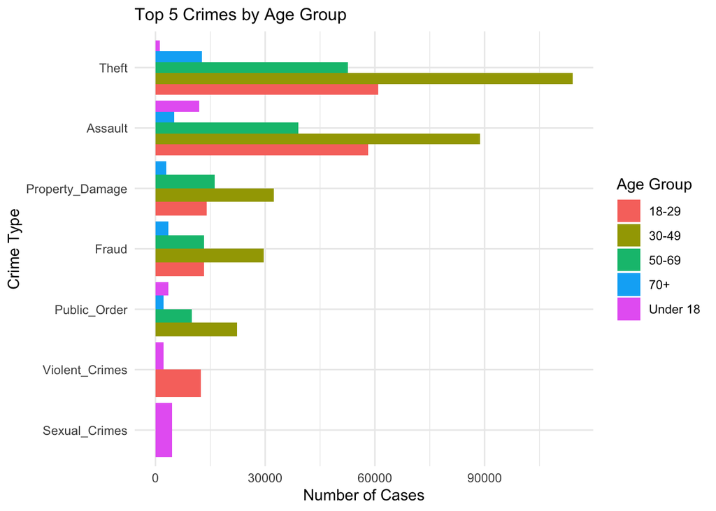

**3. Do different ethnic groups experience different types of crimes?** **Method**

To answer this, crimes were grouped into seven types as before:

- Assault (e.g., domestic assault, aggravated assault)
- Fraud (e.g., identity theft, credit card fraud)
- Property Damage (e.g., vandalism, arson)
- Public Order (e.g., stalking, resisting arrest)
- Sexual Crimes (e.g., rape, lewd conduct)
- Theft (e.g., burglary, vehicle theft)
- Violent Crimes (e.g., robbery, homicide)

A table was created to compare victim ethnicity across crime types. A Chi-Square Test was used to check if ethnicity and crime type are related.

**Analysis**

The p-value is very small (p < 0.001), confirming a strong connection between ethnicity and crime type.

The heatmap reveals that theft and assault are the most reported crimes across multiple ethnic groups, reinforcing the trends observed in the table. Ethnic minorities generally report fewer violent crimes than Hispanic and Black victims.

Observed Counts: Crime Type by Ethnicity

|  | Assault | Fraud | Property_Damage | Public_Order | Sexual_Crimes | Theft | Violent_Crimes |
| --- | --- | --- | --- | --- | --- | --- | --- |
| American Indian/Alaskan Native | 53 | 169 | 82 | 34 | 3 | 645 | 20 |
| Asian Indian | 6 | 75 | 48 | 14 | 0 | 429 | 1 |
| Black | 51798 | 14495 | 12903 | 8754 | 2025 | 34601 | 10447 |
| Cambodian | 1 | 14 | 11 | 1 | 0 | 62 | 2 |
| Chinese | 19 | 545 | 490 | 66 | 4 | 3456 | 7 |
| Filipino | 102 | 727 | 600 | 101 | 9 | 3232 | 18 |
| Guamanian | 17 | 7 | 8 | 2 | 2 | 33 | 4 |
| Hawaiian | 9 | 33 | 54 | 4 | 1 | 117 | 1 |
| Hispanic/Latin/Mexican | 109843 | 21759 | 29356 | 22645 | 5653 | 80400 | 24792 |
| Japanese | 16 | 188 | 175 | 19 | 1 | 1166 | 4 |
| Korean | 290 | 875 | 679 | 147 | 14 | 3843 | 81 |
| Laotian | 0 | 20 | 20 | 1 | 0 | 34 | 1 |
| Other Asian | 4449 | 1378 | 1790 | 1219 | 236 | 11028 | 1137 |
| Pacific Islander | 9 | 59 | 25 | 9 | 3 | 176 | 3 |
| Samoan | 3 | 20 | 4 | 2 | 0 | 26 | 3 |
| Vietnamese | 11 | 149 | 105 | 18 | 3 | 888 | 2 |
| White | 36377 | 19721 | 19317 | 14210 | 2357 | 101211 | 6965 |

Chi-Square Test Results for Ethnicity and Crime Type

| Chi-Square | DF | P-Value |
| --- | --- | --- |
| 63339.88 | 96 | 0.00e+00 |

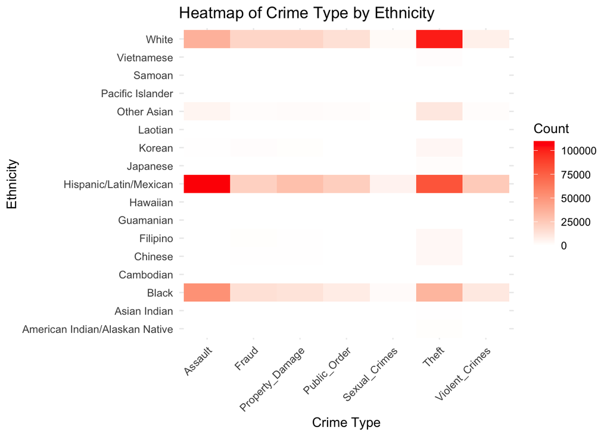

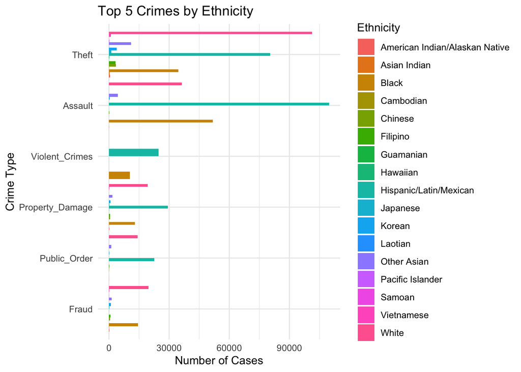

### Prediction Modeling

To predict the most likely type of crime a victim might experience, I built and compared several classification models using victim demographics and contextual features such as age, gender, ethnicity, time of occurrence, area, and type of location. The target variable was the categorized crime type. The dataset was split into training (70%), validation (15%), and testing (15%) subsets.

I began with a multinomial logistic regression model using hard-label prediction as a baseline. While it achieved a reasonable Top-1 accuracy of 46% on the test set, its performance across individual crime categories—especially those with fewer samples—was poor.

To address class imbalance, I implemented a weighted random forest model. Although the Top-1 accuracy dropped to 33%, the class-wise metrics improved notably, especially for underrepresented crime types such as fraud and sexual crimes. This tradeoff highlighted the model’s improved fairness in minority class detection, which is critical for real-world risk warnings.

Building on this, I transitioned from hard prediction to soft prediction using the probability outputs of the weighted random forest. This allowed for Top-N accuracy evaluation. I also trained an XGBoost model for comparison. Both models showed similar performance in Top-N accuracy, with Top-3 reaching over 85% and Top-5 nearing 97%. Given these results, I propose using a Top-3 prediction threshold for generating alerts in a crime risk prediction system. This approach balances predictive accuracy with actionable insight, allowing authorities or individuals to be warned about the most likely threats based on demographic profiles.

Table 1. Test Accuracy: Multinomial Logistic Regression Model

| Crime Category | Accuracy (%) |
| --- | --- |
| Overall (Validation) | 46.53 |
| Overall (Test) | 46.89 |
| Class: Assault | 66.24 |
| Class: Fraud | 11.46 |
| Class: Property_Damage | 32.96 |
| Class: Public_Order | 0.10 |
| Class: Sexual_Crimes | 0.06 |
| Class: Theft | 62.29 |
| Class: Violent_Crimes | 0.00 |

Table 2. Test Accuracy: Weighted Random Forest Model

| Crime Category | Accuracy (%) |
| --- | --- |
| Overall (Validation) | 33.54 |
| Overall (Test) | 33.65 |
| Class: Assault | 13.86 |
| Class: Fraud | 67.34 |
| Class: Property_Damage | 36.45 |
| Class: Public_Order | 27.96 |
| Class: Sexual_Crimes | 53.02 |
| Class: Theft | 37.98 |
| Class: Violent_Crimes | 53.49 |

Table 3. Top-N Accuracy (Validation & Test Sets) using Weighted Random Forest

| Top-N | Validation Accuracy (%) | Test Accuracy (%) |
| --- | --- | --- |
| Top-1 | 49.11 | 49.50 |
| Top-2 | 73.28 | 73.62 |
| Top-3 | 85.61 | 85.84 |
| Top-4 | 92.93 | 93.02 |
| Top-5 | 97.31 | 97.26 |

Table 4. Top-N Accuracy (Validation & Test Sets) using XGBoost Classifier

| Top-N | Validation Accuracy (%) | Test Accuracy (%) |
| --- | --- | --- |
| Top-1 | 49.01 | 49.07 |
| Top-2 | 73.27 | 73.58 |
| Top-3 | 85.78 | 85.92 |
| Top-4 | 93.17 | 93.12 |
| Top-5 | 97.38 | 97.34 |

## Conclusion and Summary

To build a predictive system, we trained and compared several classification models. While the multinomial logistic regression achieved decent overall accuracy, it failed to perform well on less frequent crime types. A weighted random forest model improved class-wise sensitivity, particularly for rare classes. To maximize practical use, we adopted soft prediction strategies and evaluated Top-N accuracy. Both weighted Random Forest and XGBoost showed strong performance, with Top-3 accuracy exceeding 85%.

Rather than relying on strict Top-1 predictions that may miss important risks, we propose a Top-3 alert strategy. This threshold balances precision and breadth—ensuring that likely threats are captured without overwhelming users with too many warnings. Such a strategy is practical for real-world early warning systems that support public safety and proactive interventions.

This predictive framework has potential applications in public safety, community outreach, and urban policy design. However, several limitations remain. The model does not account for dynamic factors such as recent crime spikes, neighborhood policing, or personal behavior. Additionally, prediction accuracy is constrained by data imbalance and the quality of original police reports. Future work could incorporate spatial-temporal modeling, neural networks, or external socioeconomic data to improve performance and interpretability.